# Kyochon Chicken: Digital Marketing Strategy for U.S. Expansion

Proposal Presentation

Goal Diggers Team

IBM 6400, Cal Poly Pomona

2025-03-27

# Table of Contents

- Introduction & Problem Statement
- Analytics Objectives
- Market & Competitive Analysis
- Digital Marketing Audit
- Sentiment & Content Analysis
- Data-Driven Recommendations
- References

# Introduction & Problem Statement

## Introduction

- Kyochon specializes in premium Korean fried chicken.
- Strength in Korea, growing in U.S. market.

## Problem Statement

- Lack of data-driven insights for mainstream consumers.
- Niche market vs. broader casual dining opportunities.
- Need for strategic adaptation to maintain market growth.

# Analytics Objectives

1. **Analyze the Casual Dining & Fried Chicken Markets in LA** *(Stacey)*
2. **Evaluate Kyochon Chicken’s Digital Marketing Performance** *(June)*
3. **Assess Brand Perception Through Sentiment Analysis** *(Liz)*
4. **Develop Data-Driven Digital Marketing Recommendations** *(Angel)*

# Market & Competitive Analysis

## Industry Overview

- Korean fried chicken market growing due to K-culture influence.
- Need for localized strategies in U.S. expansion.

## Competitive Landscape

- Strengths: Authentic flavors, ethical ingredients, strong Koreatown presence.
- Weaknesses: Premium pricing, digital presence lags competitors, no plant-based options.
- Threats: Competitor promotions, suburban expansion, rising demand for plant-based meals.

## Market Analysis Methods

- **Porter’s Five Forces**: Threat of new entrants, bargaining power of suppliers/buyers.
- **GIS Mapping**: Identifying high-traffic areas and customer demographics.
- **Market Segmentation**: Analyzing customer data (demographics, psychographics, behaviors).

# Digital Marketing Audit

## Current Strategies

- **Website & SEO**: Needs better optimization for key terms.
- **Paid Search & Social Ads**: Google Ads, refining social targeting.
- **Email & Loyalty Marketing**: Implementing targeted campaigns.
- **Influencer Marketing**: Collaborating with K-culture food influencers.

## Performance Analysis

- **AIDA Model**: Tracking customer journey from attention to conversion.
- **SEO Audit**: Evaluating mobile responsiveness, site speed, and content engagement.

# Sentiment & Content Analysis

## Data Sources

- Web scraping of **Google Reviews & Yelp** for customer insights.
- Tracking customer sentiment changes over time.

## Key Metrics

- **Review Sentiment Analysis**: Positive, neutral, negative classification.
- **Average Star Rating Trends**: Understanding customer satisfaction levels.
- **Engagement Metrics**: CTRs, social interactions, campaign effectiveness.

```r
library(ggplot2)
data <- data.frame(rating = c(5, 4, 3, 2, 1), count = c(120, 80, 40, 20, 10))
ggplot(data, aes(x=factor(rating), y=count)) +
  geom_bar(stat="identity", fill="steelblue") +
  theme_minimal() +
  labs(title="Customer Ratings Distribution", x="Star Rating", y="Count")
```

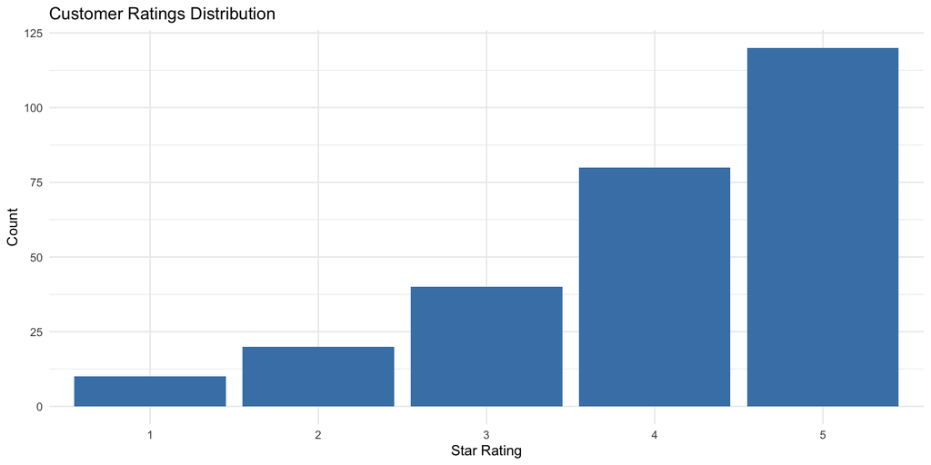

# Analytics Methods

- **AO1 (Market Analysis):**
  - Porter’s Five Forces
  - GIS Mapping
- **AO2 (Digital Audit):**
  - AIDA Model
  - SEO & UX Analysis
- **AO3 (Brand Perception):**
  - Sentiment Analysis using NLP
  - Comparative Benchmarking
- **AO4 (Recommendations):**
  - Digital Marketing Funnel Framework
  - Customer Journey Mapping

# Plan of Methods for Each Objective

- **AO1:** Examine market forces and customer segmentation.
- **AO2:** Audit digital channels (website, social media, paid ads) and measure KPIs.
- **AO3:** Analyze sentiment from reviews and compare brand perceptions.
- **AO4:** Develop targeted recommendations using data-driven insights.

# Recommendations

- **Social Media:** Launch TikTok campaigns and boost Instagram activity.
- **SEO & Website:** Optimize keywords, improve mobile usability, and enhance UX.
- **Customer Engagement:** Implement loyalty programs and personalized email marketing.
- **Operational Efficiency:** Improve response times and overall service quality.

# Asides & Footnotes

> **Note:** A strong digital presence is essential for capturing today’s market.

> *Footnote:* See Browning et al. (2013) for insights on the influence of online reviews.

# References

- Armstrong G, Kotler P, Harker M, Brennan R. *Marketing: An Introduction*. Pearson, 2022.
- Chaffey D, Ellis-Chadwick F. *Digital Marketing: Strategy, Implementation, and Practice*. Pearson, 2022.
- IBISWorld. *Fast Food Restaurants in the U.S.*, 2024.